# DENDRO mutation detection with GATK

**DENDRO** uses the following approach in the original paper to generate the initial mutation profiles across genes and cells. We write [an example script](https://github.com/zhouzilu/DENDRO/blob/master/script/mutation_detection_mapreduce.sh) modified from one real data analysis. Just want to clarify that I am not an expert with GATK tool. However, given significant amount of tests and failures, the following pipeline works for DENDRO. See [HaplotypeCaller document](https://software.broadinstitute.org/gatk/documentation/tooldocs/3.8-0/org_broadinstitute_gatk_tools_walkers_haplotypecaller_HaplotypeCaller.php) for more information.

## Questions, Suggestions & Problems

If you have any questions or problems when using DENDRO or DENDROplan, please feel free to open a new issue [here](https://github.com/zhouzilu/DENDRO/issues). You can also email the maintainers of the corresponding packages – the contact information is shown under Developers & Maintainers.

## Pipeline overview

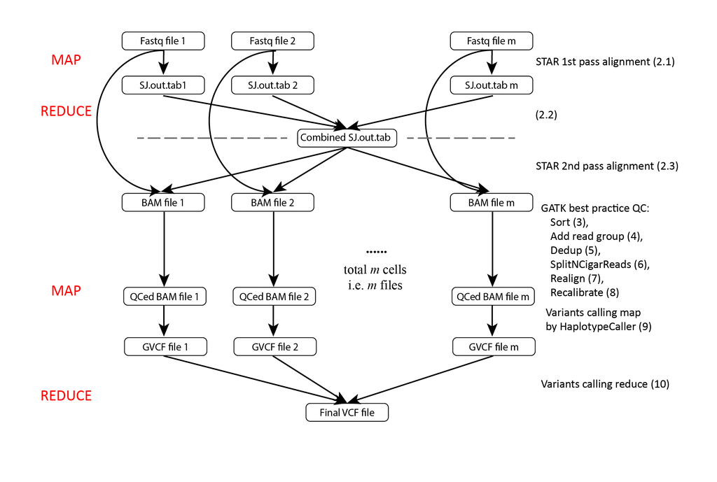

Due to great number of cells, traditional way of calling variants sample by sample is extremely slow. Luckily, GATK has ERC GVCF mode, which utilize a map-reduce like approach. Please check the details [here](https://gatkforums.broadinstitute.org/gatk/discussion/3893/calling-variants-on-cohorts-of-samples-using-the-haplotypecaller-in-gvcf-mode). Our script is built upon ERC GVCF mode togehter with the [variant detection best approach on RNAseq data](https://gatkforums.broadinstitute.org/gatk/discussion/3892/the-gatk-best-practices-for-variant-calling-on-rnaseq-in-full-detail).

Example script is attached [here](https://github.com/zhouzilu/DENDRO/blob/master/script/mutation_detection_mapreduce.sh).

## Citation

Please cite DENDRO.

- **DENDRO**: [no link yet](https://doi.org/10.1093/bioinformatics/bty057)  
  Genetic Heterogeneity Profiling by Single Cell RNA Sequencing ([GitHub](https://github.com/zhouzilu/DENDRO))

## Developers & Maintainers

- [Zilu Zhou](https://statistics.wharton.upenn.edu/profile/zhouzilu/) (zhouzilu at pennmedicine dot upenn dot edu)  
  Genomics and Computational Biology Graduate Group, University of Pennsylvania
- [Nancy R. Zhang](https://statistics.wharton.upenn.edu/profile/nzh/) (nzh at wharton dot upenn dot edu)  
  Department of Statistics, University of Pennsylvania